# xwMOOC 데이터 제품

앱 게임 - 구글 플레이(Google Play)

xwMOOC

Tidyverse Korea

2019-01-24

# 1 Google Play Store Apps 데이터 [^1]

[캐글, “Google Play Store Apps -Web scraped data of 10k Play Store apps for analysing the Android market.”](https://www.kaggle.com/lava18/google-play-store-apps/home) 웹사이트에서 약 4개월전에 Google Play Store를 통해서 공개된 데이터를 다운로드하여 분석한다.

## 1.1 데이터 정제작업

데이터를 불러와서 분석이 가능한 형태로 문자형 변수를 숫자형으로 변환시킨다.

```r
library(tidyverse)
library(janitor)
library(lubridate)

gps_dat <- read_csv("data/googleplaystore.csv") %>%
  clean_names()

gps_df <- gps_dat %>%
  mutate(installs = parse_number(installs),
         size = parse_number(ifelse(str_detect(size, "k"), 0, size)),
         reviews = as.numeric(reviews),
         price = parse_number(price),
         last_updated = mdy(last_updated),
         min_android_ver = ifelse(str_detect(android_ver, "Varies with device"), NA, android_ver),
         min_android_ver = str_extract(min_android_ver, "^[0-9]\\.[0-9]")) %>%
  filter(type %in% c("Free", "Paid"))
```

## 1.2 `NA` 및 중복데이터

중복된 행이 있는지 확인하고 결측값(`NA`)이 변수를 검사한다. “Varies with device”를 `NA`로 치환했기 때문에 발생된 경우다. `rating`이 없는 경우는 설치수(`installs`)가 적어서 발생된 경우다.

```r
gps_df %>%
  summarise_all(funs(sum(is.na(.))))  %>%
  gather(`변수`, `결측값`) %>%
  filter(`결측값` > 0) %>%
  arrange(desc(`결측값`))
```

```
# A tibble: 6 x 2
  변수            결측값
  <chr>            <int>
1 size              1694
2 rating            1473
3 min_android_ver   1363
4 category             1
5 genres               1
6 current_ver          1
```

```r
gps_eda_df <- gps_df %>%
  drop_na() %>%
  select(app, category, rating, reviews, size, installs, type, price, content_rating, genres, last_updated, min_android_ver) %>%
  group_by(app) %>%
  arrange(desc(last_updated)) %>%
  mutate(index = row_number()) %>%
  filter(index == 1) %>%
  ungroup()

# gps_df <- gps_eda_df[duplicated(gps_eda_df), ]
```

# 2 탐색적 데이터 분석(EDA)

데이터프레임에 담긴 데이터에 대한 정제작업이 끝나게 되면 $X$, $Y$에 대한 인과관계 설정 및 추가로 필요한 상관분석을 포함한 분석 모형을 구축하게 된다.

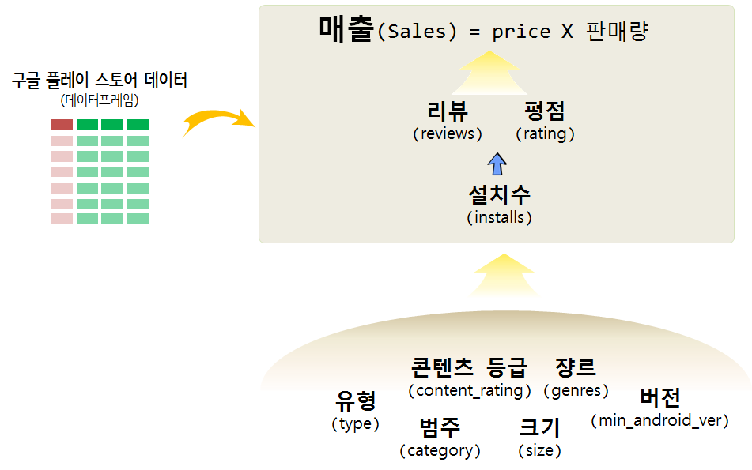

## 2.1 평점(`rating`)과 리뷰(`reviews`) 관계

평점(`rating`)과 리뷰(`reviews`)는 평점이 올라감에 따라 리뷰건수도 증가하는 관계가 보이지만 특정 평점 4.5를 넘어서면 리뷰건수가 줄어드는 것이 확인된다.

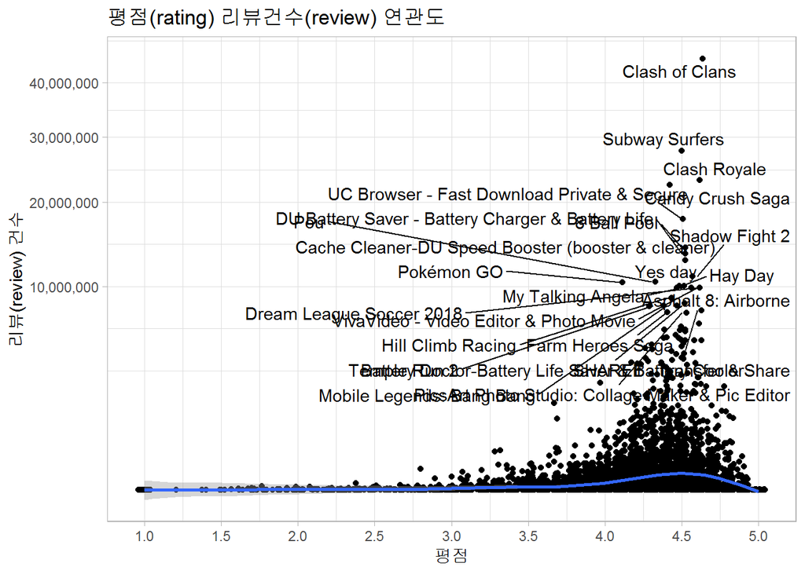

```r
library(ggrepel)

gps_eda_df %>%
  ggplot(aes(x=rating, y=reviews, label=app)) +
    geom_jitter() +
    geom_smooth() +
    scale_x_continuous(breaks = seq(0,5,0.5)) +
    scale_y_sqrt(labels = scales::comma) +
    theme_light(base_family = "NanumGothic") +
    labs(x="평점", y="리뷰(review) 건수", title="평점(rating) 리뷰건수(review) 연관도",
         color="개발사") +
    theme(legend.position = "none")  +
    geom_text_repel(data = gps_eda_df %>% filter(reviews > 7500000))
```

## 2.2 설치수(`installs`)와 리뷰(`reviews`) 관계

당연할 수 있지만 설치수(`installs`)와 리뷰(`reviews`) 관계는 설치수가 늘어나면 리뷰수가 증가하지만 일정 설치수 이상되는 경우 표본이 매우 작아 더 이상 증가된다고 보기는 어려운 점이 있는데 설치수는 많으나 리뷰가 적은 몇몇 앱에 대해서는 추가 조사가 필요해 보인다.

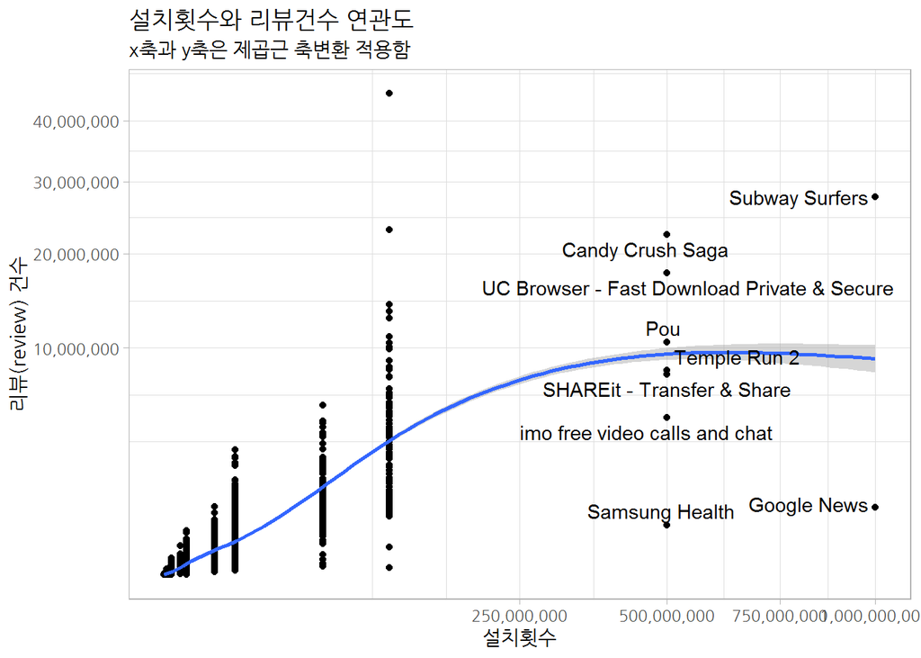

```r
library(extrafont)
loadfonts()
library(ggrepel)

gps_eda_df %>%
  ggplot(aes(y=reviews, x=installs, label=app)) +
    geom_point()+
    geom_smooth() +
    scale_x_sqrt(labels = scales::comma) +
    scale_y_sqrt(labels = scales::comma) +
    theme_light(base_family = "NanumGothic") +
    labs(x="설치횟수", y="리뷰(review) 건수", title="설치횟수와 리뷰건수 연관도",
         subtitle="x축과 y축은 제곱근 축변환 적용함",
         color="개발사") +
    theme(legend.position = "none")  +
    geom_text_repel(data = gps_eda_df %>% filter(installs > 250000000))
```

# 3 설치(`install`)에 영향을 주는 요인

```r
library(randomForest)

gps_mod_df <- gps_eda_df %>%
  select(rating, reviews, installs, type, price, content_rating, min_android_ver, category, genres) %>%
  mutate_if(is.character, as.factor) %>%
  mutate(category = fct_lump(category, 10),
         genres   = fct_lump(genres, 10))

gps_install_rf <- randomForest(installs ~ ., data= gps_mod_df, importance=TRUE, na.action=na.omit)

importance(gps_install_rf) %>%
  as.data.frame() %>%
  rownames_to_column(var="variable") %>%
  arrange(desc(`%IncMSE`))
```

```
         variable    %IncMSE IncNodePurity
1         reviews 17.7843120  2.616745e+18
2          rating  8.0694223  3.246902e+17
3            type  1.2343631  5.015209e+15
4          genres  0.7720646  7.627000e+16
5           price  0.7160945  4.483111e+15
6 min_android_ver -0.4930964  1.675532e+17
7        category -1.9891785  1.301942e+17
8  content_rating -3.3622619  7.891313e+16
```

`reviews`, `rating`, `price` 변수를 대상으로 설치건수(`installs`) 상관을 시각화하면 다음과 같다.

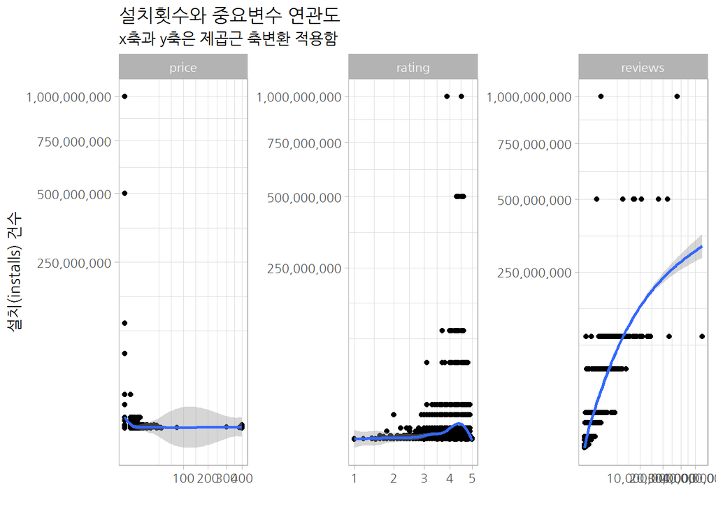

```r
gps_eda_df %>%
  select(installs, reviews, rating, price) %>%
  gather(key, value, -installs) %>%
  ggplot(aes(x=value, y=installs, group=key)) +
    geom_point()+
    geom_smooth() +
    scale_x_sqrt(labels = scales::comma) +
    scale_y_sqrt(labels = scales::comma) +
    theme_light(base_family = "NanumGothic") +
    labs(x="", y="설치(installs) 건수", title="설치횟수와 중요변수 연관도",
         subtitle="x축과 y축은 제곱근 축변환 적용함",
         color="개발사") +
    theme(legend.position = "none")  +
    facet_wrap(~key, scale="free")
```

# 4 결론 및 제언

설치건수(`install`)을 높이기 위해서 가격을 무료에 가깝게 하고 등급(`rating`)을 4.0~4.5사이에 위치시키고, 리뷰건수를 높인다.

[^1]: [Google Play Store EDA (plotting with Highcharts)](https://www.kaggle.com/danilodiogo/google-play-store-eda-plotting-with-highcharts)